# Assignment 1: Estimating CDF and PDF

Sabah Khan

Due: February 3rd, 2026

#### **Question 1**

##### a) Writing an R Function for ECDF and validating using R’s ecdf function

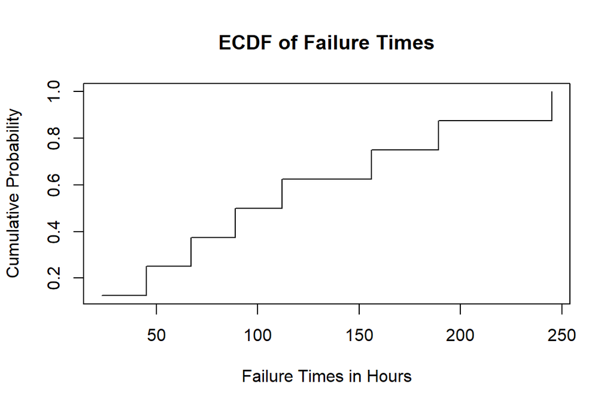

```r
times <- c(23, 45, 67, 89, 112, 156, 189, 245)
uniq.time <- sort(unique(times))

my.ECDF <- function(indat, outx){

  freq.table <- table(indat)
  uniq <- as.numeric(names(freq.table))
  rep.time <- as.vector(freq.table)
  cum.rel.feq <- cumsum(rep.time)/sum(rep.time)
  cum.prob <- NULL
  for (i in 1:length(outx)){
    intvl.id <- which(uniq <= outx[i])
    cum.prob[i] <- cum.rel.feq[max(intvl.id)]
  }
  cum.prob
}
plot(uniq.time, my.ECDF(indat = times, outx = uniq.time), type = "s",
     main = "ECDF of Failure Times",
     xlab = "Failure Times in Hours",
     ylab = "Cumulative Probability")
```

```r
ecdf(times)
```

```
Empirical CDF
Call: ecdf(times)
 x[1:8] =     23,     45,     67,  ...,    189,    245
```

##### The ECDF seems to have been set up correctly when comparing the steps in the graph to the numerical values in the ECDF vector for numerical values.

##### b) A colleague claims that the probability of failure before 100 hours is 0.5 based on these data. Do you agree? Explain your reasoning using the empirical cumulative distribution function (ECDF).

##### I agree with my colleague. When looking at the numerical values in the vector containing failure times, we see values 23, 45, 67, 89, 112, 156, 189, and 245. Of these values, 4 are below 100, and 4 are above 100, representing a 50% chance, or 0.5 probability of failure before 100 hours and also a 0.5 probability of failure above 100 hours.

#### **Question 2**

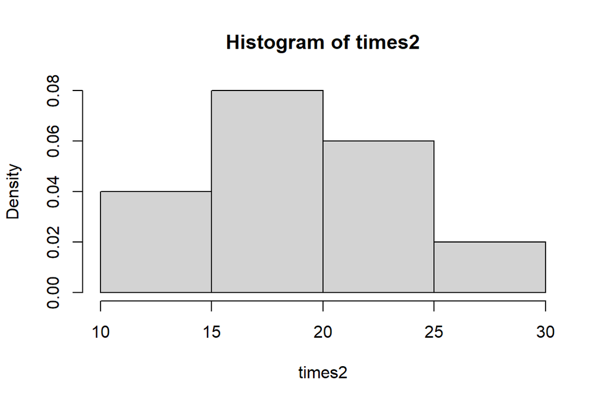

```r
times2 <- c(12.3, 14.7, 15.2, 16.8, 18.1, 19.4, 20.6, 22.3, 23.9, 25.4)

hist(times2, breaks = 3, freq = FALSE)
```